# Lab S4 - Working on the command line in Terminal with Shell

## Learning Objectives

In this lesson, you will learn:

- Learn basic shell commands to navigate, manage files, and perform simple tasks in the terminal.

## Introduction to the Shell and Terminal

The **terminal** is a text-based interface that allows users to interact with their computer by typing commands. It’s a powerful tool for controlling the system, running programs, and managing files.

The **shell** is the program that interprets these commands. When you open a terminal window, you’re typically interacting with a shell—commonly **bash** (Bourne Again SHell), though others like **zsh**, **fish**, or **sh** may be used.

### Key Concepts:

- **Prompt**: The line where you type commands, often ending in `$` for regular users or `#` for root.
- **Commands**: Instructions you give to the shell, like `ls` (list files), `cd` (change directory), or `mkdir` (make directory).
- **Arguments**: Extra information passed to commands, e.g., `ls -l` lists files in long format.
- **Pipes and Redirection**: You can chain commands (`|`) or redirect output (`>` or `<`) to files.
- **Scripts**: You can write shell scripts—text files with a series of commands—to automate tasks.

### Why Use the Shell?

- **Efficiency**: Perform tasks faster than with a graphical interface.
- **Automation**: Easily automate repetitive tasks.
- **Remote Access**: Manage systems over SSH.
- **Control**: Fine-grained control over system behavior and configuration.

## Accessing the Shell and Terminal on Unity

On Microsoft’s Windows and Apple’s OSX there are terminal programs available, but user’s in those communities rarely use the terminal to run shell commands.

There are many ways to access the Shell and Terminal on Unity.

1. You can access the shell directly without launching a new job.

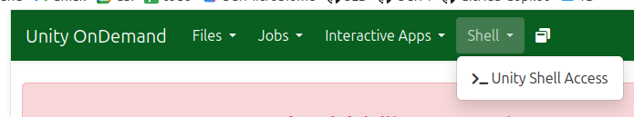

[figure not shown]

2. In RStudio the terminal is available in the bottom left quadrant

[figure not shown]

3. Using JypterLab

[figure not shown]

## Shell Tutorial

### Getting started

- On Unity under `Interactive Apps` Open a `JupyterLab` session
- In the `Launcher` start a terminal session.

**Try This:**

- Type: echo “Hello, world!”
- This prints text to the screen.

### Navigating the Filesystem

**Key Commands:**

- `pwd` – Print current directory.
- `ls` – List files.
- `cd` – Change directory.

**Try This:**

```
$ pwd

$ ls

$ cd \~        \# Go to home directory

$ cd /        \# Go to root directory

$ cd -        \# Go back to previous directory

$ cd pathogen         \# To move into a directory

$ cd ..         \# To go up one directory
```

**Tips:**

- Use `ls -l` for detailed listing.
- Use `ls -a` to show hidden files.

### Working with Files and Directories

**Key Commands:**

- `touch` – Create a file.
- `mkdir` – Make a directory.
- `rm` – Remove a file.
- `rmdir` – Remove a directory.
- `cp` – Copy files.
- `mv` – Move or rename files.

**Try This:**

```
$ mkdir test_folder

$ cd test_folder

$ touch file1.txt

$ ls

$ cp file1.txt file2.txt

$ mv file2.txt renamed.txt

$ rm file1.txt

$ cd ..

$ rmdir test_folder

**Caution:** `rm` deletes files permanently. Use with care.
```

### Viewing and Editing Files

**Key Commands:** - `cat` – View file contents. - `less` – Scroll through file. - `nano` – Simple text editor.

**Try This:**

```
$ touch test.txt

$ echo "This is a test file." > test.txt

$ cat test.txt

## To exit type `q`

$ less test.txt

## To exit type `q`

$ nano test.txt

## To exit `type`ctr x`
```

**Tip:** Press `Ctrl+X` to exit `nano`.

### Useful Tools and Shortcuts

**Key Concepts:**

- `man` – Manual pages.
- `history` – View command history.
- `clear` – Clear terminal screen.
- Tab completion – Auto-complete file names.
- Arrow keys – Navigate command history.

**Try This:**

```
$ man ls

$ history

$ clear
```

**Bonus:**

- Use `grep` to search inside files:

```
$ grep "test" test.txt
```

## Exercises

Complete the above commands. Open a text file and save as `myhistory.txt`. Type `history` into the shell as above. Copy and paste the history into the `myhistory.txt` file. Download the file to your computer and then upload the file to Canvas.